# Question

Al momento de realizar un viaje por carretera, un repartidor registró cuidadosamente los siguientes parámetros durante su recorrido:

| Tiempo (horas) | Costo del viaje (miles de pesos) | Combustible disponible (litros) | Distancia recorrida (kilómetros) |
| --- | --- | --- | --- |
| 0 | 0 | 50 | 0 |
| 2 | 29 | 34 | 18 |
| 4 | 60 | 21 | 34 |
| 6 | 74 | 1 | 53 |
| 8 | 92 | 0 | 73 |

Después de analizar los datos del viaje, se generaron diversas interpretaciones gráficas. ¿Cuál de las siguientes gráficas representa INCORRECTAMENTE la relación entre la distancia recorrida y el combustible disponible en función del tiempo, considerando las características físicas del desplazamiento y el consumo esperado del vehículo?

## Answerlist

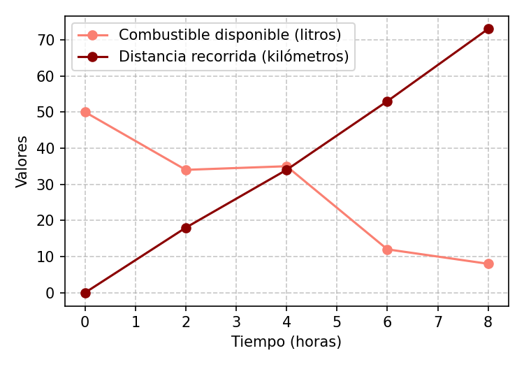

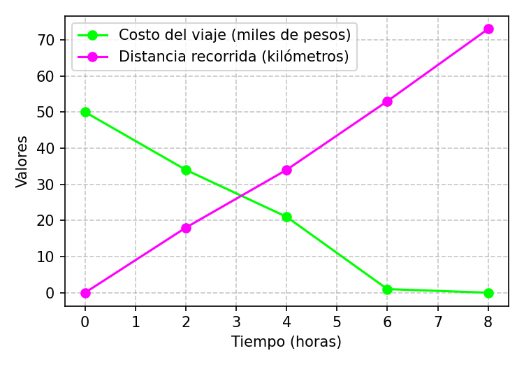

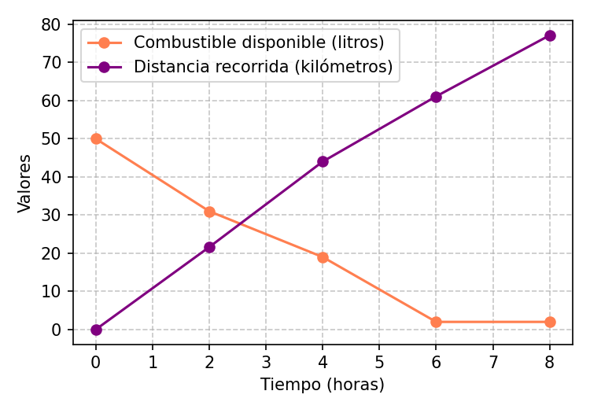

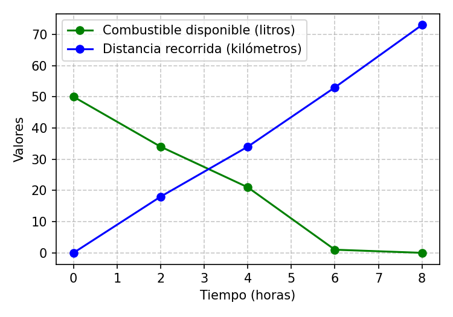

# Solution

Para determinar la gráfica incorrecta, es necesario analizar las relaciones físicas y matemáticas que gobiernan el movimiento del vehículo y su consumo de combustible:

1. **Comportamiento del combustible**: Al examinar los datos, se observa una disminución progresiva desde 50 litros al inicio hasta 0 litros al final. Esta reducción es consistente con el consumo esperado de un vehículo en movimiento continuo, donde el combustible se consume a una tasa aproximadamente proporcional al tiempo y distancia recorrida.
2. **Comportamiento de la distancia**: Los datos muestran un incremento sistemático desde 0 km hasta 73 km. Este incremento sigue un patrón aproximadamente lineal, lo que sugiere una velocidad media relativamente constante durante el viaje.
3. **Relación entre variables**: La relación inversamente proporcional entre combustible disponible (decreciente) y distancia recorrida (creciente) representa el fenómeno físico de conversión de energía química del combustible en energía cinética y trabajo mecánico.

La gráfica incorrecta es la que muestra:

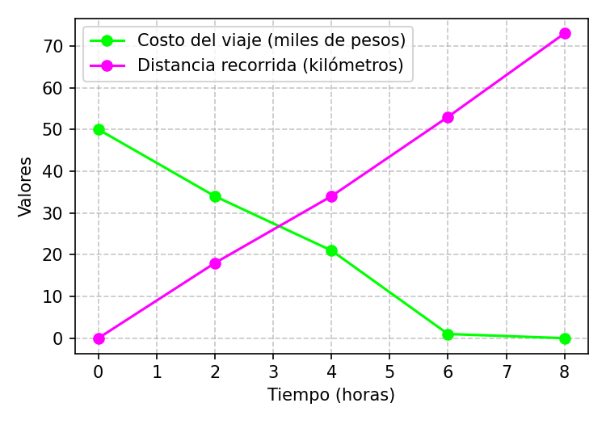

Esta gráfica es incorrecta porque:

- Aunque los datos representados siguen el patrón correcto (una línea decreciente y otra creciente), la etiqueta “Costo del viaje” es errónea para la línea decreciente.
- El costo del viaje debería aumentar con el tiempo y la distancia recorrida, no disminuir.
- Los datos mostrados corresponden realmente al combustible disponible, que sí disminuye a medida que avanza el viaje.

## Answerlist

# Meta-information